# sslr_tsa_11slides

## Deriving data-driven HbA1c strata

BIOS PROJECT #1589 · METHODS PRESENTATION

Deriving data-driven HbA1c strata

Stratum-specific likelihood ratios  
for 90-day complications after primary TSA

Jian He

Department of Biostatistics · School of Public Health  
Virginia Commonwealth University

01 / 11

## Study Background, Aim, and Data

One primary goal to identify TSA-specific HbA1c strata

- Diabetes associated with complications after joint arthroplasty
- Diabetes and outcomes following total shoulder arthroplasty (TSA) pooly defined
- Hemoglobin A1c (HbA1c) a biomarker for diabetes
- Pre-operative HbA1c thresholds from one clinical population not transportable
- 20,757 patient records from TriNetX
  - Adults underwent primary TSA Jan. 1, 2016–Jan. 1, 2026
  - Pre-operative HbA1c recorded within 90 days

Address that primary goal using stratum-specific likelihood ratios (SSLRs)

02 / 11

## Fundamentals

- $\mathrm{Likelihood}(H|\mathrm{data}) = K\cdot\mathrm{Pr}(\mathrm{data}|H)$
- H a hypothesis and K an arbitrary constant
- Likelihoods NOT obey the laws of probability
- Likelihood ratio for $H_0$ vs. $H_1 | \mathrm{data}$
  $$= \frac{K\cdot\mathrm{Pr}(\mathrm{data}|H_0)}{K\cdot\mathrm{Pr}(\mathrm{data}|H_1)}$$
- A dichotomous test ($T+$ and $T-$) and binary disease states ($D+$ and $D-$)
  $$LR+ = \frac{\mathrm{Pr}(T+|D+)}{\mathrm{Pr}(T+|D-)} \quad \quad LR- = \frac{\mathrm{Pr}(T-|D+)}{\mathrm{Pr}(T-|D-)}$$

03 / 11

## Notation

| Symbol | Definition |
| --- | --- |
| $X$ | Pre-operative HbA1c (%) |
| $Y$ | Infection by 90 days: 1=yes; 0=no |
| $S_g$ | HbA1c interval; $g=1,\ldots,G$ |
| $G$ | Number of intervals |
| $n_1,n_0$ | Total event / non-event counts |
| $a_g,b_g$ | Event / non-event counts in $S_g$ |

| Symbol | Definition |
| --- | --- |
| $q_{1g}$ | $P(X\in S_g\mid Y=1)$ |
| $q_{0g}$ | $P(X\in S_g\mid Y=0)$ |
| $LR_g$ | Stratum likelihood ratio: $q_{1g}/q_{0g}$ |
| $\pi$ | Overall outcome risk: $P(Y=1)$ |
| $p_g$ | Stratum risk: $P(Y=1\mid X\in S_g)$ |
| $\widehat{LR}_g$ | estimated SSLR for stratum $g$ |

TPR = true-positive rate; FPR = false-positive rate; $\Delta$ = change.

04 / 11

## SSLR Computation and Interpretation

$$LR_g =
\frac{P(X\in S_g\mid Y=1)}
{P(X\in S_g\mid Y=0)}$$

**Estimation from observed counts**

$$\widehat{LR}_g = \frac{a_g/n_1}{b_g/n_0}$$

**Bayesian revision of odds**

$$\frac{\mathrm{Pr}(Y=1|X \in S_g)}{\mathrm{Pr}(Y=0|X \in S_g)} = \frac{\mathrm{Pr}(X \in S_g|Y=1)}{\mathrm{Pr}(X \in S_g|Y=0)} \times \frac{\mathrm{pr}(Y=1)}{\mathrm{pr}(Y=0)}$$

$>1$: being in $g$ increases odds of infection relative to the overall pretest odds

Notation

| Symbol | Definition |
| --- | --- |
| $X$ | Pre-op HbA1c |
| $Y$ | Infection (0/1) |
| $S_g$ | HbA1c interval |
| $n_1,n_0$ | Total cases/noncases |
| $a_g,b_g$ | Cases/noncases in $S_g$ |
| $\pi$ | Overall risk |
| $p_g$ | Risk within $S_g$ |
| $LR_g$ | Stratum likelihood ratio |

05 / 11

## SSLR as Slopes of ROC Curve Segments

Single cutoff: one point on the ROC curve defines two straight-line slopes

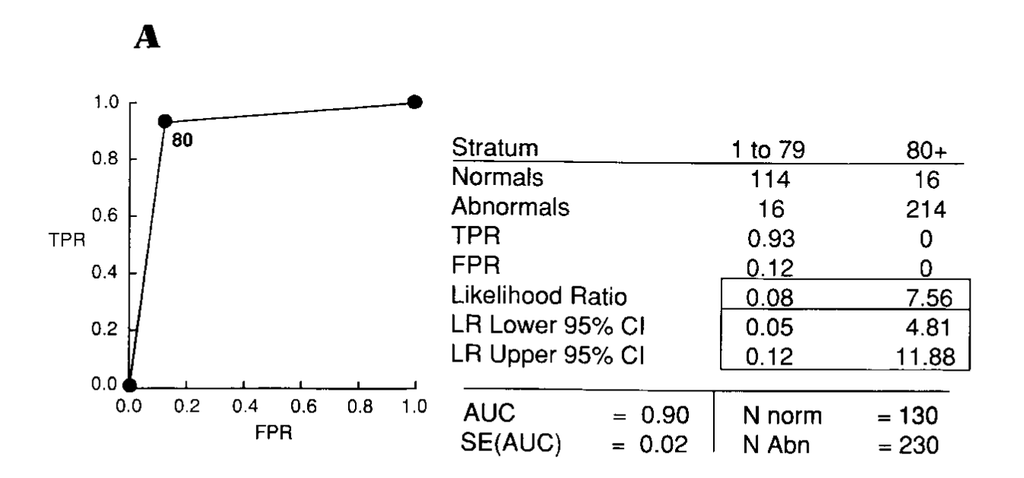

**Generalization to $g$ stratum**

$$\Delta \mathrm{TPR}_g=\frac{a_g}{n_1},
\quad
\Delta \mathrm{FPR}_g=\frac{b_g}{n_0},
\quad
\text{Segment slope}_g
=
\frac{\Delta \mathrm{TPR}_g}{\Delta \mathrm{FPR}_g}
=
\widehat{LR}_g$$

Notation & Abbreviations

| Symbol | Definition |
| --- | --- |
| TPR | true-positive rate |
| FPR | false-positive rate |
| $a_g,b_g$ | event / non-event counts in stratum $g$ |
| $n_1,n_0$ | total event / non-event counts |
| $\Delta$ | change contributed by one stratum |
| $\widehat{LR}_g$ | estimated SSLR for stratum $g$ |

HbA1c $\uparrow$, SSLR $\uparrow$

ROC left $\rightarrow$ right: segment slopes $\downarrow$

06 / 11

## Variance Via Delta Method and 95% CI for SSLR

Notation

$q_{1g},q_{0g}$: stratum proportions among cases/noncases

$\widehat q_{1g},\widehat q_{0g}$: estimated proportions

$a_g,b_g$: interval cases/noncases

$n_1,n_0$: total cases/noncases

$\widehat{LR}_g$: estimated SSLR

$$\begin{gathered}
a_g\sim\mathrm{Binomial}(n_1,q_{1g}),\quad
b_g\sim\mathrm{Binomial}(n_0,q_{0g}),\\
\widehat q_{1g}=\frac{a_g}{n_1},\quad
\widehat q_{0g}=\frac{b_g}{n_0},\quad
\mathrm{Var}(\widehat q_{1g})=\frac{q_{1g}(1-q_{1g})}{n_1}
\end{gathered}$$

$$\log\widehat q_{1g}
\approx \log q_{1g}
+\frac{1}{q_{1g}}(\widehat q_{1g}-q_{1g})$$

$$\mathrm{Var}(\log\widehat q_{1g})
\approx \frac{1}{q_{1g}^{2}}
\frac{q_{1g}(1-q_{1g})}{n_1},\quad
\widehat{\mathrm{Var}}(\log\widehat q_{1g})
\approx \frac{1}{a_g}-\frac{1}{n_1},\quad
\widehat{\mathrm{Var}}(\log\widehat q_{0g})
\approx \frac{1}{b_g}-\frac{1}{n_0}$$

$$\log\widehat{LR}_g
=\log\left(\frac{a_g}{n_1}\right)
-\log\left(\frac{b_g}{n_0}\right), \quad
\widehat{\mathrm{Var}}(\log\widehat{LR}_g)
=\frac{1}{a_g}-\frac{1}{n_1}
+\frac{1}{b_g}-\frac{1}{n_0}$$

$$\boxed{
\mathrm{CI}_{95\%}(LR_g)=
\exp\left[
\log\widehat{LR}_g
\pm1.96\sqrt{
\widehat{\mathrm{Var}}(\log\widehat{LR}_g)
}
\right]
}$$

07 / 11

## SSLR Analysis Demo (1)

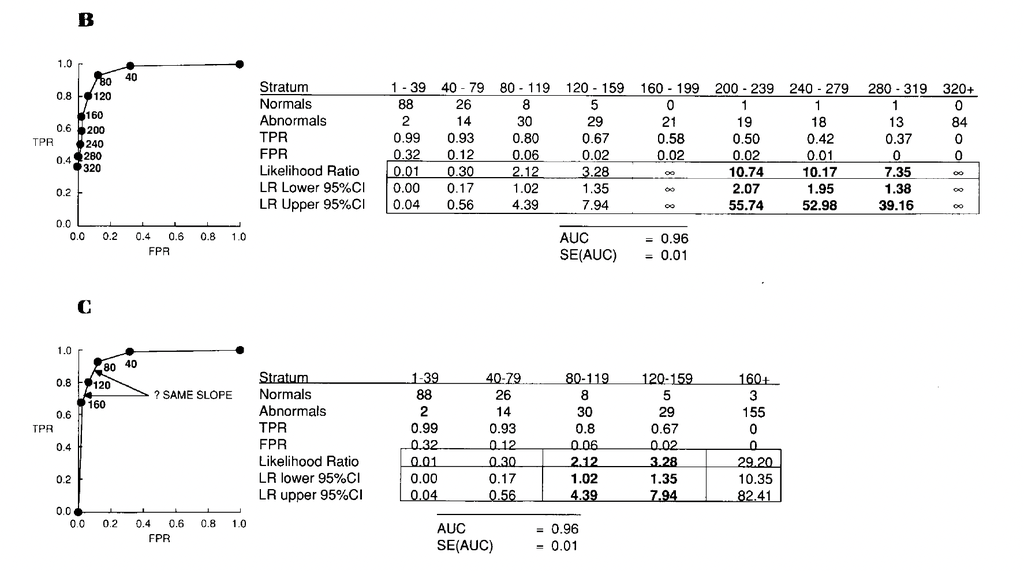

08 / 11

## SSLR Analysis Demo (2)

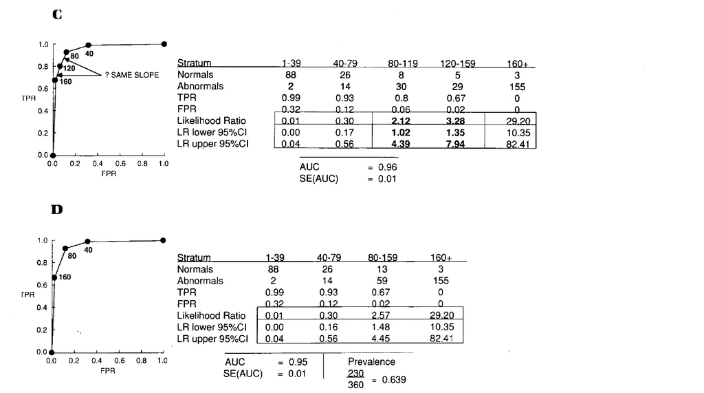

09 / 11

## Reference

**Peirce JC, Cornell RG.** Integrating stratum-specific likelihood ratios with the analysis of ROC curves. *Medical Decision Making*. 1993;13(2):141–151.  
**Method:** Eqs. 5–11 (pp. 142–143); grouping rules (p. 148).  
DOI: 10.1177/0272989X9301300208

10 / 11

## Thank you!

11 / 11